# GraphBAN蛋白药物互作预测

Wang Dengdong

2025-06-26

# 参考文献：

Hadipour, H., Li, Y.Y., Sun, Y. et al. GraphBAN: An inductive graph-based approach for enhanced prediction of compound-protein interactions. Nat Commun 16, 2541 (2025). https://doi.org/10.1038/s41467-025-57536-9

https://github.com/HamidHadipour/GraphBAN/

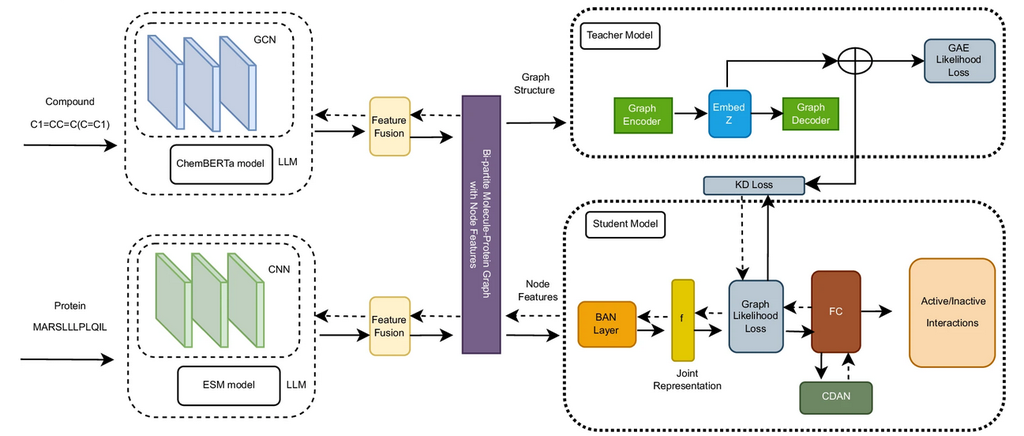

# 数据准备

1、候选基因 genes symbol

2、药物 smiles结构

# 公共数据目录

python运行环境：/data/nas2/software/miniconda3/envs/graphban

数据目录：

/data/nas2/database/graphban/

1、db目录：graphban模型、蛋白序列数据

2、bin目录：graphban程序目录

3、示例脚本：示例脚本， 数据准备GraphBNA_prepare.r、运行脚本GraphBAN.sh和结果过滤GraphBNA_filter.r

# GraphBNA_prepare.r

```r
rm(list=ls())
suppressPackageStartupMessages({
  library(rstudioapi)
  library(dplyr)
  library(tidyr)
  library(data.table)
})
conflicted::conflict_prefer_matching("^filter$|^select$|^arrange$|^mutate$|", "dplyr",quiet = T)

root <- getActiveProject()
setwd(root)
wd <- file.path(root,"04_GraphBAN")
dir.create(wd,recursive = T,showWarnings = F)
setwd(wd)
print(wd)
set.seed(123456)
```

目标基因，symbol在gene_names列，根据实际修改

```r
gene <- read.csv('../01_GWAS2Gene/02.genes.csv',row.names = 1)
```

uniprot canonical sequence，uniprot基因标准蛋白序列

```r
prot <- readRDS('/data/nas2/database/graphban/db/uniprot_pep/pep.rds')
```

提取需要的蛋白序列，保留基因名和序列

```r
prot <- prot %>%
  filter(Gene_Name %in% gene$gene_names) %>%
  select(Gene_Name,Protein)#
```

```r
head(dplyr::as_tibble(prot))
```

```
## # A tibble: 6 × 2
##   Gene_Name Protein
##   <chr>     <chr>
## 1 EIF4EBP1  MSGGSSCSQTPSRAIPATRRVVLGDGVQLPPGDYSTTPGGTLFSTTPGGTRIIYDRKFLMECRNSPV…
## 2 HTR3D     MQKHSPGPPALALLSQSLLTTGNGDTLIINCPGFGQHRVDPAAFQAVFDRKAIGPVTNYSVATHVNI…
## 3 ABCB9     MRLWKAVVVTLAFMSVDICVTTAIYVFSHLDRSLLEDIRHFNIFDSVLDLWAACLYRSCLLLGATIG…
## 4 ABHD12    MRKRTEPVALEHERCAAAGSSSSGSAAAALDADCRLKQNLRLTGPAAAEPRCAADAGMKRALGRRKG…
## 5 ABHD2     MNAMLETPELPAVFDGVKLAAVAAVLYVIVRCLNLKSPTAPPDLYFQDSGLSRFLLKSCPLLTKEYI…
## 6 ABHD16A   MAKLLSCVLGPRLYKIYRERDSERAPASVPETPTAVTAPHSSSWDTYYQPRALEKHADSILALASVF…
```

目标药物，至少需要SMILES列，可添加其他列，如id，方便识别

```r
smiles <- read.csv('../03_herbs/smiles4graphban.csv')
```

```r
head(smiles)
```

```
##          id
## 1 MOL000006
## 2 MOL000011
## 3 MOL000020
## 4 MOL000021
## 5 MOL000022
## 6 MOL000028
##                                                                                             SMILES
## 1                                                          O=c1cc(-c2ccc(O)c(O)c2)oc2cc(O)cc(O)c12
## 2                                             COc1cc([C@H]2Oc3c(OC)cc4ccc(=O)oc4c3O[C@@H]2CO)ccc1O
## 3                                            CC(C)=CC(=O)O[C@@H](/C=C/C=C/C#CC#C/C=C\\C[O-])CC[O-]
## 4                                         CC(=O)OCC[C@@H](/C=C/C=C/C#CC#C/C=C\\C[O-])OC(=O)C=C(C)C
## 5                                             CC(=O)OCC[C@H](/C=C/C=C\\C#CC#C/C=C/CO)OC(=O)C=C(C)C
## 6 C[C@H]1[C@H](C)CC[C@]2(C)CC[C@]3(C)C(=CC[C@@H]4[C@@]5(C)CC[C@H](O)C(C)(C)[C@H]5CC[C@]43C)[C@H]12
##                      InChIKey
## 1 IQPNAANSBPBGFQ-UHFFFAOYSA-N
## 2 OCBGWPJNUZMLCA-NVXWUHKLSA-N
## 3 YHOASFVUAIYTTA-PKPRIEKHSA-N
## 4 PLSLPUXBODHUFC-JAPNHWDDSA-N
## 5 CQDVFBMTEZFKKY-PUYRJQRLSA-N
## 6 FSLPMRQHCOLESF-FRCIEAHOSA-N
```